# Analyse

## Introduction

Nous avons à notre disposition un jeu de données contient des identifiants anonymisés de 4 centres commerciaux français ainsi que des identifiants de téléphones dont les propriétaires ont visité ces centres commerciaux avec la date et l'heure des différents pings observés au cours de la visite. L'objectif de l'étude est, à partir de ces données, de déterminer les horaires d'ouverture de chacun des centres pour chaque jour de la semaine. Idéalement de proposer un algorithme qui permettra de déterminer les horaires d'ouverture d'un centre ne faisant pas partie de ce dataset à partir de ses données de fréquentation; et proposer également une piste d'amélioration pertinente sur la qualité des données source.

```python
import pandas as pd
import matplotlib.pyplot as plt
import numpy as np
%matplotlib inline
```

## Importation des données

```python
# Lecture du fichier dans un DataFrame : df
df = pd.read_csv('/home/sacko/Documents/Data_analyst/Donnees/projet_analytique.csv')
```

## Exploration et nettoyage des données

```python
df.head(10)
```

[output not shown]

```python
df.drop(['Unnamed: 0'], axis=1, inplace = True)
df.shape
```

```
(81838, 5)
```

```python
df.isna().sum()
```

```
shopping_center_id    0
device_local_date     0
device_hash_id        0
day                   0
hour                  0
dtype: int64
```

```python
df.describe()
```

|  | day | hour |
| --- | --- | --- |
| count | 81838.000000 | 81838.000000 |
| mean | 3.566607 | 14.218761 |
| std | 1.898697 | 3.701902 |
| min | 1.000000 | 0.000000 |
| 25% | 2.000000 | 11.000000 |
| 50% | 3.000000 | 14.000000 |
| 75% | 5.000000 | 17.000000 |
| max | 7.000000 | 23.000000 |

```python
df.duplicated().sum()
```

```
3390
```

```python
df = df.drop_duplicates()
```

```python
df.shape
```

```
(78448, 5)
```

```python
## Premiere idee sur les donnees
print(df.info())
```

[output not shown]

## Évaluation de la quantité de données (de pings) par centre commercial

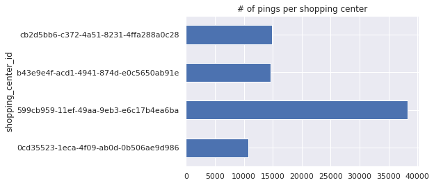

```python
df.groupby('shopping_center_id')['device_local_date'].count().plot.barh(title='# of pings per shopping center')
```

## Évaluation de la qualité des données (de pings par identifiant) par centre commercial

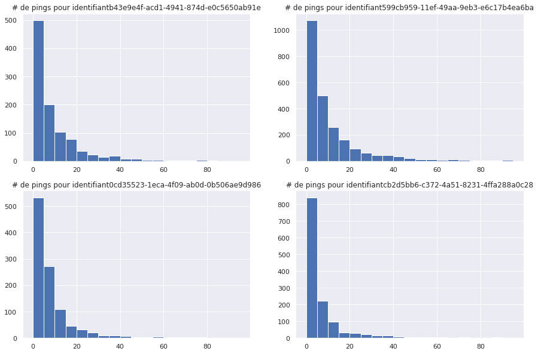

```python
shopping_centers = df.shopping_center_id.unique()
pings_per_id = df.groupby(['shopping_center_id', 'device_hash_id'])['device_local_date'].count()

fig, axs = plt.subplots(2, 2, figsize=(15, 10))

for shopping_center, ax in zip(shopping_centers, axs.flat):
    pings_per_id.loc[shopping_center].hist(ax=ax, bins=np.arange(0, 100, 5))
    ax.set_title('# de pings pour identifiant' + shopping_center)
```

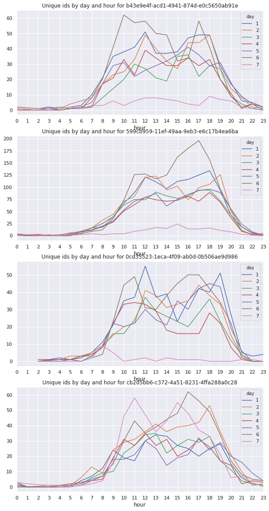

```python
ids_per_dow_hour = pd.DataFrame(df.groupby(['shopping_center_id', 'day', 'hour'])['device_hash_id'].nunique())

fig, axs = plt.subplots(4, figsize=(10, 20))

for shopping_center, ax in zip(shopping_centers, axs) :
    ids_per_dow_hour.loc[shopping_center].unstack().T.droplevel(0).sort_index().fillna(0).plot(ax=ax)
    ax.set_title('Unique ids by day and hour for ' + shopping_center)
    ax.set_xticks(np.arange(0, 24, 1))
```

## Conclusion du nettoyage et de l'exploration des données

Après avoir supprimé 3390 entrées en double qui correspondent à des personnes ayant émis plusieurs pings dans une minute donnée, le jeu de données contient 78448 pings, représentés par une date et une heure, répartis dans 4 centres commerciaux.

En termes de quantité de données (nombre de pings), l'un des 4 centres commerciaux contient environ 3 fois plus de données que les 3 autres centres commerciaux. En termes de qualité des données (nombre de pings par id), les histogrammes montrent des différences entre les centres qui pourraient avoir un impact sur les analyses avancées, mais qui ne devraient pas poser de problème pour le problème qui nous proccupe, à savoir la détermination des heures d'ouverture des centres commerciaux. La distribution du nombre d'identifiants (qui est un bon indicateur du nombre de personnes présentes dans le centre commercial) jour par jour et heure par heure est cohérente avec notre intuition : les valeurs sont les plus élevées pendant la journée et le samedi, et les plus faibles pendant la nuit et le dimanche, lorsque les centres commerciaux sont généralement fermés (sauf pour 1 des 4 centres commerciaux, qui semble être ouvert le dimanche). En partant du principe que les centres commerciaux sont plus fréquentés lorsqu'ils sont ouverts, nous devrions être en mesure de déterminer les heures d'ouverture des centres commerciaux sur la base de cet ensemble de données.

## Détermination des heures d'ouverture des centres commerciaux

En examinant les graphiques de la phase d'exploration de cette analyse, nous étudierons si le fait de fixer un percentile approprié du nombre d'identifiants dans un centre commercial permet une détection automatique des heures d'ouverture.

```python
def plot_shopping_center_ids_percentile(percentile=90):
    ids_per_dow_hour = pd.DataFrame(df.groupby(['shopping_center_id', 'day', 'hour'])['device_hash_id'].nunique())
    fig, axs = plt.subplots(4, figsize=(10, 20))

    for shopping_center, ax in zip(shopping_centers, axs) :
        plot_data = ids_per_dow_hour.loc[shopping_center].unstack().T.droplevel(0).sort_index().fillna(0)
        threshold = np.percentile(plot_data, percentile)
        plot_data.plot(ax=ax)
        ax.plot([0, 23], [threshold, threshold], linewidth=5)
        ax.set_title('Unique ids by day and hour for ' + shopping_center)
        ax.set_xticks(np.arange(0, 24, 1))
```

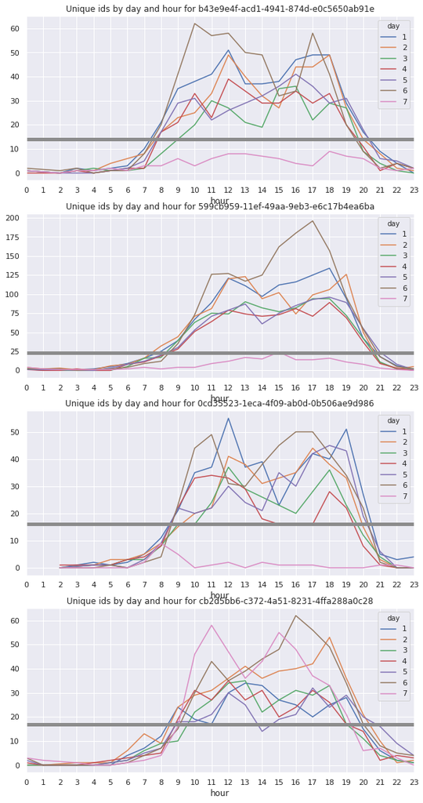

```python
plot_shopping_center_ids_percentile(55)
```

```python
def determine_opening_hours(shopping_center_id, percentile=55):
    ids_per_dow_hour = pd.DataFrame(df.groupby(['shopping_center_id', 'day', 'hour'])['device_hash_id'].nunique())
    plot_data = ids_per_dow_hour.loc[shopping_center_id].unstack().T.droplevel(0).sort_index().fillna(0)
    threshold = np.percentile(plot_data, percentile)
    res = plot_data > threshold
    return res
```

```python
for c in df.shopping_center_id.unique() :
    print('\n-----------------------------------------------------\n'+ c + '\n')
    print(determine_opening_hours(c))
```

```
-----------------------------------------------------
b43e9e4f-acd1-4941-874d-e0c5650ab91e

day       1      2      3      4      5      6      7
hour
0     False  False  False  False  False  False  False
2     False  False  False  False  False  False  False
3     False  False  False  False  False  False  False
4     False  False  False  False  False  False  False
5     False  False  False  False  False  False  False
6     False  False  False  False  False  False  False
7     False  False  False  False  False  False  False
8      True   True  False   True   True   True  False
9      True   True  False   True   True   True  False
10     True   True   True   True   True   True  False
```

[output cut: 99 more lines]

## Conclusion

Nous avons développé un algorithme qui permet de détecter les heures d'ouverture des centres commerciaux à partir des pings des téléphones portables. Notre algorithme est basé sur un seuil, défini comme le 55 ème centile du nombre d'identifiants détectés en une heure sur une semaine standard dans un centre commercial donné. Les faiblesses suivantes et les améliorations possibles sont soulignées: Il existe des pings d'employés qui sont éventuellement présents en dehors des heures d'ouverture. Ils pourraient être filtrés en détectant les identifiants présents pendant de très longues périodes de temps un jour donné, ou les personnes présentes plusieurs jours dans la semaine. Notre modèle est basé sur seulement 4 centres commerciaux. Afin de construire un modèle plus robuste, nous devrions le tester sur un plus grand nombre de centres commerciaux. Nous pourrions vérifier les heures d'ouverture réelles (sur internet, en appelant le centre commercial) et réajuster notre modèle afin de coller au mieux à la réalité.